# Data Visualization - Mini-Project 2

Heilyn Gonzalez `hramirezabreu8662@floridapoly.edu`

I have selected for this project the dataset about bad drivers in U.S. I pretend to visualize which State has the worst drivers in the country and if the number of accidents where drivers who were not distracted is considerable. I am not the best driver but I drive without exceeding the limit of speed, and I am always afraid of crashes because Floridian’s drivers are really racing and that scares me a little bit.

## Getting the data

```r
library(tidyverse)
bad_drivers<-read_csv ("https://raw.githubusercontent.com/reisanar/datasets/master/bad_drivers.csv")
```

This dataset contains the following variables:

- State
- Number of drivers involved in fatal collisions per billion miles
- Percentage of drivers involved in fatal collisions who were speeding
- Percentage of drivers involved in fatal collisions who were alcohol-impaired
- Percentage of drivers involved in fatal collisions who were not distracted
- Percentage of drivers involved in fatal collisions who had not been involved in any previous accidents
- Car insurance premiums
- Losses incurred by insurance companies for collisions per insured driver

# Summarizing the data

After getting the data, it is time to formatting the data because the columns “perc_speeding”, “perc_alcohol”, “perc_not_distracted” and so on, are percentages of “num_drivers (number of drivers involved in fatal accidents)”. I will mutate some new columns in the following step:

```r
bad_drivers<-bad_drivers%>%
  mutate(speeding_drivers=(num_drivers*perc_speeding)/100)%>%
  mutate(alchol_drivers=(num_drivers*perc_alcohol)/100)%>%
  mutate(notdistracted_drivers=(num_drivers*perc_not_distracted)/100)%>%
  mutate(noprevious_drivers=(num_drivers*perc_no_previous)/100)
```

# Plotting the data

Below will be a Treemap that will show us the number of bad drivers in U.S grouping by State.

[figure not shown]

```r
library(ggplot2)
library(treemapify)

treemap1<- ggplot(bad_drivers, aes(area = num_drivers, fill = state, label = paste(state, num_drivers, separate = " "))) +
  geom_treemap(show.legend = FALSE) +
  geom_treemap_text(fontface = "italic", colour = "white", place = "topleft", grow = FALSE) +
  labs(title = "Number of Bad Drivers in U.S", subtitle = "Per State")

treemap1
```

I will create some barplots for analyzing the data and see what are the major percentage of drivers involved in fatal collisions, and which state has the most of them.

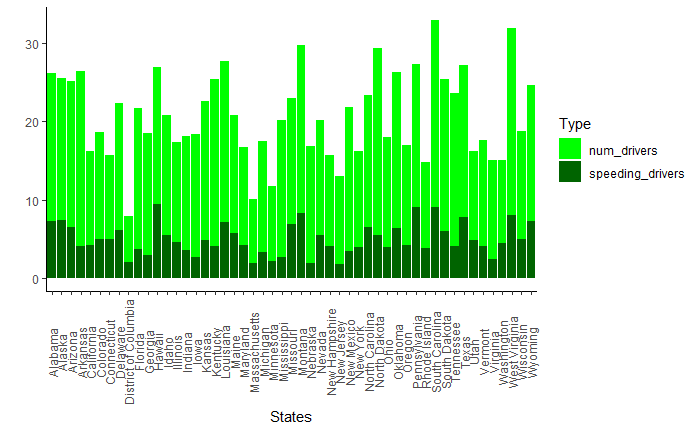

```r
speedbarplot<-bad_drivers %>%
  select(state, num_drivers, speeding_drivers) %>%
  gather(type, value, num_drivers:speeding_drivers) %>%
  ggplot(., aes(x = state,y = value, fill = type)) + labs(fill="Type") +
  geom_bar(position = "stack", stat="identity") +
  scale_fill_manual(values = c("green", "darkgreen")) + xlab("States") +
  ylab("") + theme_minimal() + theme_classic() +
  theme(axis.text.x=element_text(angle=90, vjust=0.5))


speedbarplot
```

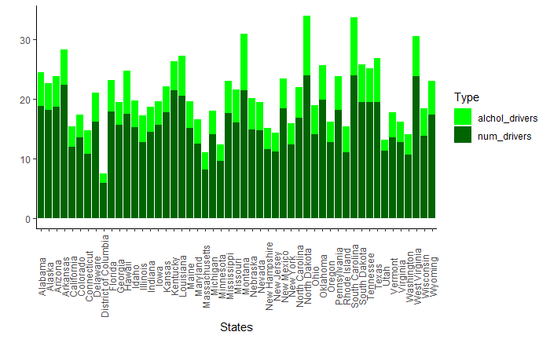

```r
alcoholbarplot<-bad_drivers %>%
  select(state, num_drivers, alchol_drivers) %>%
  gather(type, value, num_drivers:alchol_drivers) %>%
  ggplot(., aes(x = state,y = value, fill = type)) + labs(fill="Type") +
  geom_bar(position = "stack", stat="identity") +
  scale_fill_manual(values = c("green", "darkgreen")) + xlab("States") +
  ylab("") + theme_minimal() + theme_classic() +
  theme(axis.text.x=element_text(angle=90, vjust=0.5))

alcoholbarplot
```

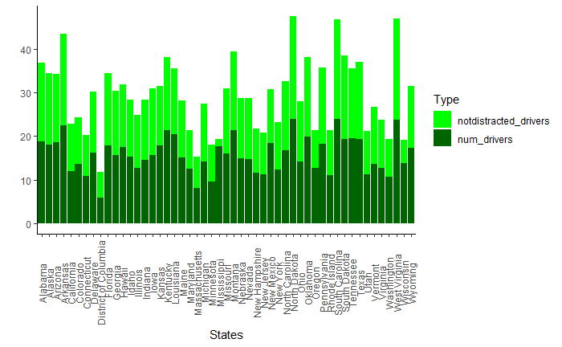

```r
notdistractedbarplot<-bad_drivers %>%
  select(state, num_drivers, notdistracted_drivers) %>%
  gather(type, value, num_drivers:notdistracted_drivers) %>%
  ggplot(., aes(x = state,y = value, fill = type)) + labs(fill="Type") +
  geom_bar(position = "stack", stat="identity") +
  scale_fill_manual(values = c("green", "darkgreen")) + xlab("States") +
  ylab("") + theme_minimal() + theme_classic() +
  theme(axis.text.x=element_text(angle=90, vjust=0.5))

notdistractedbarplot
```

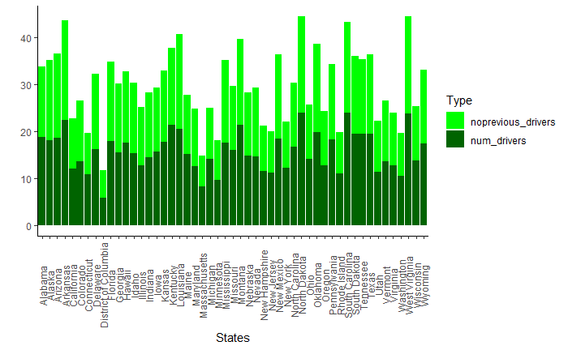

```r
nopreviousbarplot<-bad_drivers %>%
  select(state, num_drivers, noprevious_drivers) %>%
  gather(type, value, num_drivers:noprevious_drivers) %>%
  ggplot(., aes(x = state,y = value, fill = type)) + labs(fill="Type") +
  geom_bar(position = "stack", stat="identity") +
  scale_fill_manual(values = c("green", "darkgreen")) + xlab("States") +
  ylab("") + theme_minimal() + theme_classic() +
  theme(axis.text.x=element_text(angle=90, vjust=0.5))


nopreviousbarplot
```

```r
NA
NA
```

Let’s see what happens with alcohol drivers that are involved in fatal collisions and insurance premiums.

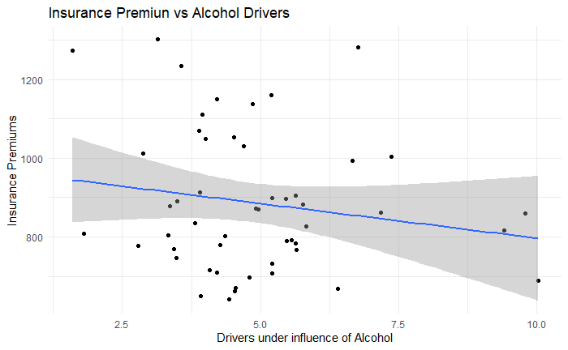

```r
plot1<-ggplot(data=bad_drivers, mapping = aes(x=alchol_drivers,y=insurance_premiums)) +
  geom_point() + geom_smooth(method=lm)+
  labs(title = "Insurance Premiun vs Alcohol Drivers", x = "Drivers under influence of Alcohol", y = "Insurance Premiums") +
  theme(legend.title = element_blank(), legend.position = "none") + theme_minimal()

plot1
```

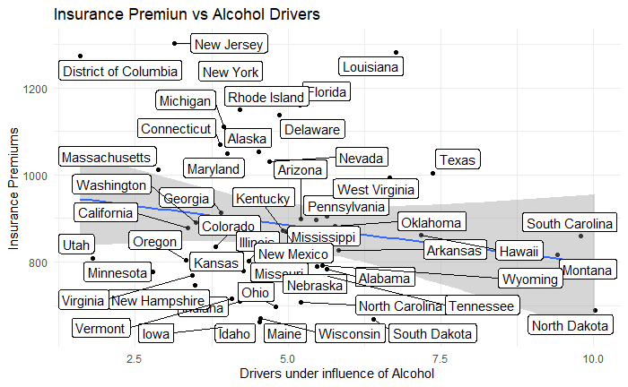

```r
plot2<- plot1 + geom_label_repel(aes(label = state))
plot2
```

```r
NA
NA
NA
```

## Map

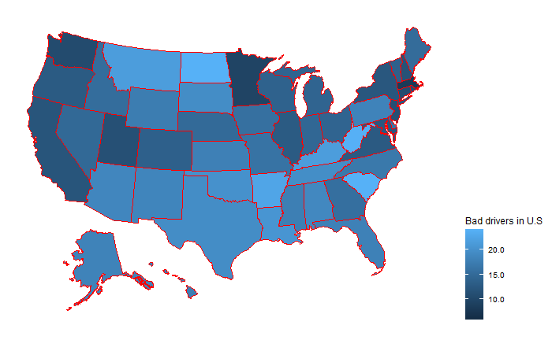

```r
library(plotly)
library(ggrepel)
library(sf)
library(usmap)


baddrivers_map<- plot_usmap(data = bad_drivers, values = "num_drivers", color = "red") +
  scale_fill_continuous(name = "Bad drivers in U.S", label = scales::comma) +
  theme(legend.position = "right")

baddrivers_map
```

```r
NA
NA
NA
```